# Final Project

2026-10-26

## Preparing data

To begin my analysis, I will look at the legislation data provided by the U.S. Data Center Policy Explorer. The values in the `status` column can be very specific, but I want the five-value policy stages as presented on the website. To get this, I look through the data and see which statuses correspond to which stages and used `mutate()` to create a new `stage` column. i used `count()` to make sure that I get the same counts in my data frame as there are on the website, and I do.

```r
legislation <- read_csv("filtered-data-center-policies.csv")
proposed <- c("Introduced", "Introduced (repeal of existing provision)", "Proposed")
in_committee <- c("In Committee", "In Committee (Left pending in subcommittee on Fiscal Matters, 04/11/2013)", "In Committee (re-referred to Appropriations, April 8, 2019; Finance Committee reported as committed 8-3)", "In Committee (Study Bill)")
advanced <- c("Approved", "Crossed Over", "Engrossed", "Engrossed (passed Senate; left in Rules in House; not enacted)", "Passed", "Passed (Act No. 175 of 2016, Nov. 21, 2016)", "Passed (enacted as Chapter 85, approved May 23, 2025)", "Passed (resolution authorizing bill introduction)", "Postponed Indefinitely", "Substituted by A5662", "Substituted by S4293")
enacted <- c("Enacted", "Enacted (expired June 30, 2011)", "Enacted (veto overridden, Chapter 3 of 2025 Special Session)", "Incorporated", "Signed", "Signed/Enacted", "Signed/Enacted (expired June 30, 2020)", "Signed/Enacted (provision for equipment purchased or leased on or before June 30, 2011; MOU window January 1, 2008 – December 31, 2008)")
legislation <- legislation %>% mutate(stage=ifelse(status %in% proposed,"Proposed / Introduced",ifelse(status %in% in_committee, "In Committee",ifelse(status %in% advanced, "Advanced",ifelse(status %in% enacted, "Enacted", "Vetoed")))))
legislation %>% count(stage=="Proposed / Introduced")
```

```
## # A tibble: 2 × 2
##   `stage == "Proposed / Introduced"`     n
##   <lgl>                              <int>
## 1 FALSE                                504
## 2 TRUE                                 111
```

```r
legislation %>% count(stage=="In Committee")
```

```
## # A tibble: 2 × 2
##   `stage == "In Committee"`     n
##   <lgl>                     <int>
## 1 FALSE                       315
## 2 TRUE                        300
```

```r
legislation %>% count(stage=="Advanced")
```

```
## # A tibble: 2 × 2
##   `stage == "Advanced"`     n
##   <lgl>                 <int>
## 1 FALSE                   520
## 2 TRUE                     95
```

```r
legislation %>% count(stage=="Enacted")
```

```
## # A tibble: 2 × 2
##   `stage == "Enacted"`     n
##   <lgl>                <int>
## 1 FALSE                  515
## 2 TRUE                   100
```

```r
legislation %>% count(stage=="Vetoed")
```

```
## # A tibble: 2 × 2
##   `stage == "Vetoed"`     n
##   <lgl>               <int>
## 1 FALSE                 606
## 2 TRUE                    9
```

Next, I add the ten policy categories as separate columns in the table. The `topics` column lists any of the ten policy topics the bill covers. By creating ten logical vectors as columns, the data can be filtered more easily for later analysis. This can be done using `str_detect()` on the `topics` column. Looking at the results using `head()` shows that this method returns the desired result.

```r
legislation <- legislation %>% mutate(cost_allocation=str_detect(legislation$topics,"Cost allocation and ratepayer protection"),disclosure=str_detect(legislation$topics,"Disclosure and transparency"),energy=str_detect(legislation$topics,"Energy and grid planning"),eia=str_detect(legislation$topics,"Environmental impact assessment (EIA)"),fiscal=str_detect(legislation$topics,"Fiscal instruments"),governance=str_detect(legislation$topics,"Governance and authority"),ban=str_detect(legislation$topics,"Prohibitions/Bans"),definition=str_detect(legislation$topics,"Regulated entity definition"),performance_standard=str_detect(legislation$topics,"Resource performance standard"),siting=str_detect(legislation$topics,"Siting and land use"))
legislation %>% select(bill,topics,cost_allocation,disclosure,energy,eia,fiscal,governance,ban,definition,performance_standard,siting) %>% head()
```

```
## # A tibble: 6 × 12
##   bill   topics  cost_allocation disclosure energy eia   fiscal governance ban
##   <chr>  <chr>   <lgl>           <lgl>      <lgl>  <lgl> <lgl>  <lgl>      <lgl>
## 1 HB 399 Regula… FALSE           FALSE      FALSE  FALSE TRUE   FALSE      FALSE
## 2 HB403  Regula… TRUE            FALSE      FALSE  FALSE FALSE  FALSE      FALSE
## 3 SB265  Regula… FALSE           FALSE      FALSE  FALSE TRUE   FALSE      FALSE
## 4 SB270  Regula… TRUE            FALSE      TRUE   FALSE FALSE  TRUE       FALSE
## 5 SB250  Cost a… TRUE            FALSE      FALSE  FALSE TRUE   TRUE       TRUE
## 6 HB2119 Prohib… FALSE           TRUE       FALSE  FALSE TRUE   TRUE       TRUE
## # ℹ 3 more variables: definition <lgl>, performance_standard <lgl>,
## #   siting <lgl>
```

## Data centers

A list of over 1,000 data centers from around the country is provided by the Data Driven EnviroLab. The data set provides the location, owner, operator, and historical operational status of each data center listed.

```r
data_centers <- read_csv("Campuses.csv")
head(data_centers)
```

```
## # A tibble: 6 × 21
##   ddl_id   lat   lon state reported_owner reported_operator confirmed_datacenter
##   <chr>  <dbl> <dbl> <chr> <chr>          <chr>             <chr>
## 1 AL1     34.8 -86.6 AL    Meta           Starbelt LLC      Yes
## 2 AL2     34.9 -85.7 AL    Google         Wiessner Enterpr… Yes
## 3 AL3     34.7 -86.7 AL    Alabama Super… Alabama Supercom… Yes
## 4 AL4     31.2 -85.5 AL    AngelTrax      AngelTrax         Yes
## 5 AL5     33.4 -86.9 AL    Sungard Syste… Sungard Systems … Yes
## 6 AL6     34.7 -86.7 AL    SimpleHelix    SimpleHelix       Yes
## # ℹ 14 more variables: `2015` <chr>, `2016` <chr>, `2017` <chr>, `2018` <chr>,
## #   `2019` <chr>, `2020` <chr>, `2021` <chr>, `2022` <chr>, `2023` <chr>,
## #   `2024` <chr>, `2025` <chr>, previous_land_use <chr>,
## #   multiple_buildings <chr>, address <chr>
```

```
## ℹ Using `zoom = 4`
## ℹ © Stadia Maps © Stamen Design © OpenMapTiles © OpenStreetMap contributors.
```

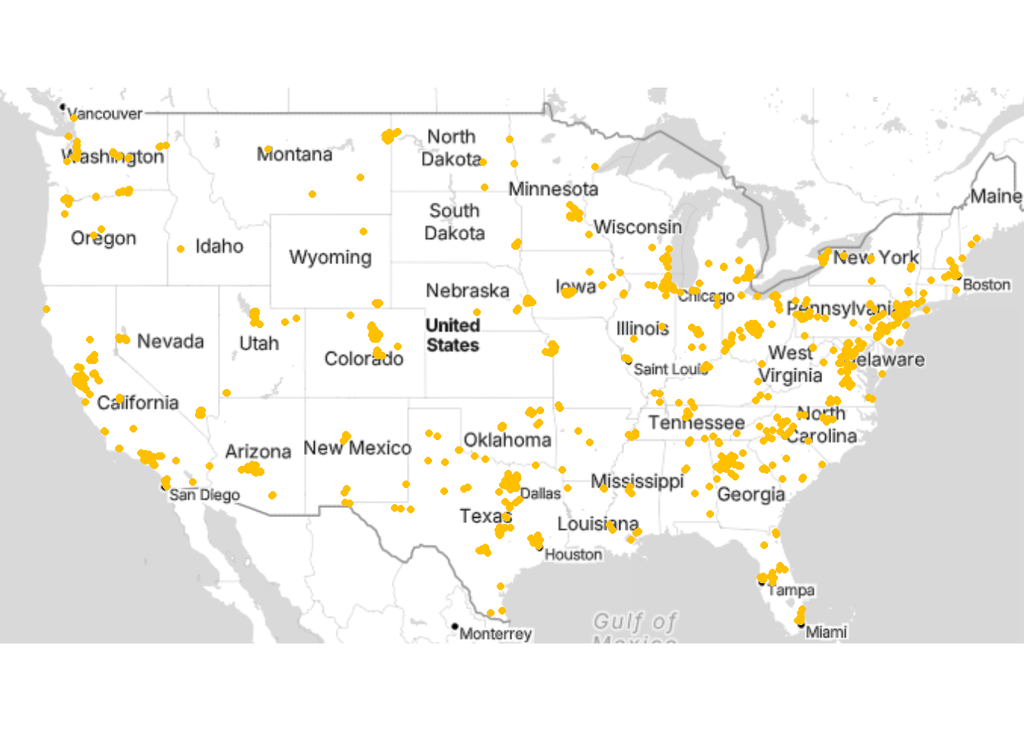

```r
qmplot(data=data_centers, x=lon, y=lat, color=I("#ffc000"))
```

Not all data centers are created equally. The main driving force behind recent public backlash and policy response is hyperscale data centers, which are used for AI training and are generally of recent construction. Therefore, to narrow the scope of the data centers used in the analysis, the data set will be filtered to include those which were being expanded or newly built from 2022 to 2025. The data can be further narrowed down by looking at the owner or operator of the data center and selecting those which are known hyperscale data center providers or excluding known telecom and webhosting data center providers.

```r
new_construction <- c("Expansion", "Under Construction")
new_data_centers <- data_centers %>% filter(`2022` %in% new_construction | `2023` %in% new_construction | `2024` %in% new_construction | `2025` %in% new_construction)
head(data_centers)
```

```
## # A tibble: 6 × 21
##   ddl_id   lat   lon state reported_owner reported_operator confirmed_datacenter
##   <chr>  <dbl> <dbl> <chr> <chr>          <chr>             <chr>
## 1 AL1     34.8 -86.6 AL    Meta           Starbelt LLC      Yes
## 2 AL2     34.9 -85.7 AL    Google         Wiessner Enterpr… Yes
## 3 AL3     34.7 -86.7 AL    Alabama Super… Alabama Supercom… Yes
## 4 AL4     31.2 -85.5 AL    AngelTrax      AngelTrax         Yes
## 5 AL5     33.4 -86.9 AL    Sungard Syste… Sungard Systems … Yes
## 6 AL6     34.7 -86.7 AL    SimpleHelix    SimpleHelix       Yes
## # ℹ 14 more variables: `2015` <chr>, `2016` <chr>, `2017` <chr>, `2018` <chr>,
## #   `2019` <chr>, `2020` <chr>, `2021` <chr>, `2022` <chr>, `2023` <chr>,
## #   `2024` <chr>, `2025` <chr>, previous_land_use <chr>,
## #   multiple_buildings <chr>, address <chr>
```

```
## ℹ Using `zoom = 4`
```

```
## ℹ © Stadia Maps © Stamen Design © OpenMapTiles © OpenStreetMap contributors.
```

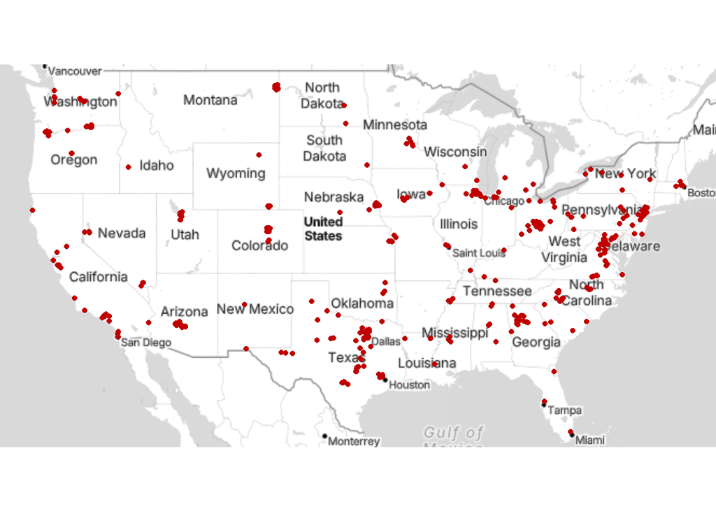

```r
qmplot(data=new_data_centers, x=lon, y=lat, color=I("#c00000"))
```

## Census data

Before and after data will be taken from the 2019 and 2024 ACS. We are looking at these variables: *B19013_001 = Median Household Income* B15003_001 & B15003_022 = Educational Attainment (Total Pop & Bachelor’s Degree) *B01002_001 = Median Age* B19058_001 & B19058_002 = SNAP Assistance (Total Pop & True) *B23025_001, B23025_005, & B23025_007 = Employment Status (Total Pop, Unemployed, & Not in Labor Force)* B02001_001, B02001_002, & B02001_003 = Race (Total Pop, White, and Black) *B03003_001 & B03003_003 = Hispanic/Latino (Total Pop & True)

The code below loads this data by county, but will be viewed on the census tract level as well. County-level data is a placeholder so that the code loads faster.

```r
census_2024 <- get_acs(geography="county", geometry=TRUE, variables=c("B19013_001","B15003_001","B15003_022", "B01002_001", "B19058_001", "B19058_002", "B23025_001", "B23025_005", "B23025_007", "B02001_001", "B02001_002", "B02001_003", "B03003_001", "B03003_003"), output="wide")
census_2024 <- census_2024 %>%
  select(-ends_with("M")) %>%
  rename(`Income`= B19013_001E, `Education Pop` = B15003_001E, `Bachelor's` = B15003_022E, `Age` = B01002_001E, `SNAP Pop` = B19058_001E, `SNAP Users` = B19058_002E, `Employment Pop` = B23025_001E, `Unemployed` = B23025_005E, `Not in Labor Force` = B23025_007E, `Race Pop` = B02001_001E, `White` = B02001_002E, `Black` = B02001_003E, `Hispanic Pop` = B03003_001E, `Hispanic` = B03003_003E)
census_2019 <- get_acs(year=2019, geography="county", geometry=TRUE, variables=c("B19013_001","B15003_001","B15003_022", "B01002_001", "B19058_001", "B19058_002", "B23025_001", "B23025_005", "B23025_007", "B02001_001", "B02001_002", "B02001_003", "B03003_001", "B03003_003"), output="wide")
census_2019 <- census_2019 %>%
  select(-ends_with("M")) %>%
  rename(`Income`= B19013_001E, `Education Pop` = B15003_001E, `Bachelor's` = B15003_022E, `Age` = B01002_001E, `SNAP Pop` = B19058_001E, `SNAP Users` = B19058_002E, `Employment Pop` = B23025_001E, `Unemployed` = B23025_005E, `Not in Labor Force` = B23025_007E, `Race Pop` = B02001_001E, `White` = B02001_002E, `Black` = B02001_003E, `Hispanic Pop` = B03003_001E, `Hispanic` = B03003_003E)
```

Here I can map which counties have data centers with `st_join()`.

```r
head(census_2024)
```

```
## Simple feature collection with 6 features and 16 fields
## Geometry type: MULTIPOLYGON
## Dimension:     XY
## Bounding box:  xmin: -88.47323 ymin: 30.99708 xmax: -75.04894 ymax: 38.96187
## Geodetic CRS:  NAD83
##   GEOID                    NAME Income Education Pop Bachelor's  Age SNAP Pop
## 1 01069 Houston County, Alabama  58626         74980      10923 40.3    43302
## 2 01023 Choctaw County, Alabama  47813          9003        938 47.4     5255
## 3 01113 Russell County, Alabama  51197         39900       4907 37.5    23938
## 4 10005 Sussex County, Delaware  81497        193708      36534 51.9   106441
## 5 01071 Jackson County, Alabama  51908         37972       3747 43.5    21795
## 6 01089 Madison County, Alabama  86499        278833      77118 38.2   165031
##   SNAP Users Employment Pop Unemployed Not in Labor Force Race Pop  White Black
## 1       7178          86158       2231              36307   108140  69848 29442
## 2        919          10208        246               5322    12380   7025  4649
## 3       4830          45919       1512              20234    58811  26947 26810
## 4      11898         214861       6180              98576   255626 189534 25415
## 5       2813          43230        994              20968    53053  46884  1680
## 6      13176         327935       7631             115484   405718 255719 96997
##   Hispanic Pop Hispanic                       geometry
## 1       108140     4984 MULTIPOLYGON (((-85.71209 3...
## 2        12380      144 MULTIPOLYGON (((-88.47323 3...
## 3        58811     3527 MULTIPOLYGON (((-85.4347 32...
## 4       255626    29438 MULTIPOLYGON (((-75.7226 38...
## 5        53053     1897 MULTIPOLYGON (((-86.15423 3...
## 6       405718    27577 MULTIPOLYGON (((-86.78955 3...
```

```r
data_center_coords <- new_data_centers %>% filter(!is.na(lon), !is.na(lat)) %>%
  st_as_sf(
    coords = c("lon", "lat"),
    crs = 4269
  )
data_center_merged <- st_join(data_center_coords,census_2024)
data_center_merged %>% select(ddl_id,GEOID,NAME) %>% head()
```

```
## Simple feature collection with 6 features and 3 fields
## Geometry type: POINT
## Dimension:     XY
## Bounding box:  xmin: -111.8823 ymin: 32.2732 xmax: -86.32813 ymax: 34.84321
## Geodetic CRS:  NAD83
## # A tibble: 6 × 4
##   ddl_id GEOID NAME                                   geometry
##   <chr>  <chr> <chr>                               <POINT [°]>
## 1 AL1    01089 Madison County, Alabama    (-86.62822 34.84321)
## 2 AL5    01073 Jefferson County, Alabama  (-86.91146 33.40472)
## 3 AL7    01073 Jefferson County, Alabama    (-86.821 33.50052)
## 4 AL8    01089 Madison County, Alabama    (-86.69288 34.70995)
## 5 AL10   01101 Montgomery County, Alabama  (-86.32813 32.2732)
## 6 AZ1    04013 Maricopa County, Arizona   (-111.8823 33.26908)
```

```r
census_with_centers <- census_2024 %>% mutate(data_center = ifelse(NAME %in% data_center_merged$NAME,TRUE,FALSE))
census_with_centers %>% select(GEOID,NAME,data_center) %>% head()
```

```
## Simple feature collection with 6 features and 3 fields
## Geometry type: MULTIPOLYGON
## Dimension:     XY
## Bounding box:  xmin: -88.47323 ymin: 30.99708 xmax: -75.04894 ymax: 38.96187
## Geodetic CRS:  NAD83
##   GEOID                    NAME data_center                       geometry
## 1 01069 Houston County, Alabama       FALSE MULTIPOLYGON (((-85.71209 3...
## 2 01023 Choctaw County, Alabama       FALSE MULTIPOLYGON (((-88.47323 3...
## 3 01113 Russell County, Alabama       FALSE MULTIPOLYGON (((-85.4347 32...
## 4 10005 Sussex County, Delaware       FALSE MULTIPOLYGON (((-75.7226 38...
## 5 01071 Jackson County, Alabama       FALSE MULTIPOLYGON (((-86.15423 3...
## 6 01089 Madison County, Alabama        TRUE MULTIPOLYGON (((-86.78955 3...
```

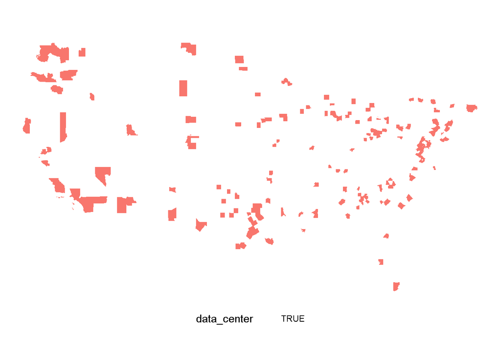

```r
census_with_centers %>% filter(data_center==TRUE) %>% ggplot(aes(fill=data_center)) + geom_sf(size=NA) + theme_void() + theme(legend.position = "bottom")
```